# Blood Pressure Example

Alexandra Chronopoulou

Lecture 11 WLS Example

A health researcher interested in studying the relationship between diastolic blood pressure and age among healthy women 20 to 60 years old, collected data on 54 subjects.

```r
pressure <- read.table("blood_pressure.txt", header=FALSE)
names(pressure)=c("age", "pressure")
head(pressure)
```

```
##   age pressure
## 1  27       73
## 2  21       66
## 3  22       63
## 4  24       75
## 5  25       71
## 6  23       70
```

We start by fitting a linear regression:

```r
lm.pressure = lm(pressure~age, data=pressure)
summary(lm.pressure)
```

```
##
## Call:
## lm(formula = pressure ~ age, data = pressure)
##
## Residuals:
##      Min       1Q   Median       3Q      Max
## -16.4786  -5.7877  -0.0784   5.6117  19.7813
##
## Coefficients:
##             Estimate Std. Error t value Pr(>|t|)
## (Intercept) 56.15693    3.99367  14.061  < 2e-16 ***
## age          0.58003    0.09695   5.983 2.05e-07 ***
## ---
## Signif. codes:  0 '***' 0.001 '**' 0.01 '*' 0.05 '.' 0.1 ' ' 1
##
## Residual standard error: 8.146 on 52 degrees of freedom
## Multiple R-squared:  0.4077, Adjusted R-squared:  0.3963
## F-statistic: 35.79 on 1 and 52 DF,  p-value: 2.05e-07
```

The estimators for the slope and intercept are statistically significant, the $F$-test for regression has a low p-value, which means that the predictor (Age) significant in estimating the response. The $R^2$ is relatively low, around 40% indicating a weak relationship between age and blood pressure.

We can also plot the raw data and the fitted regression line:

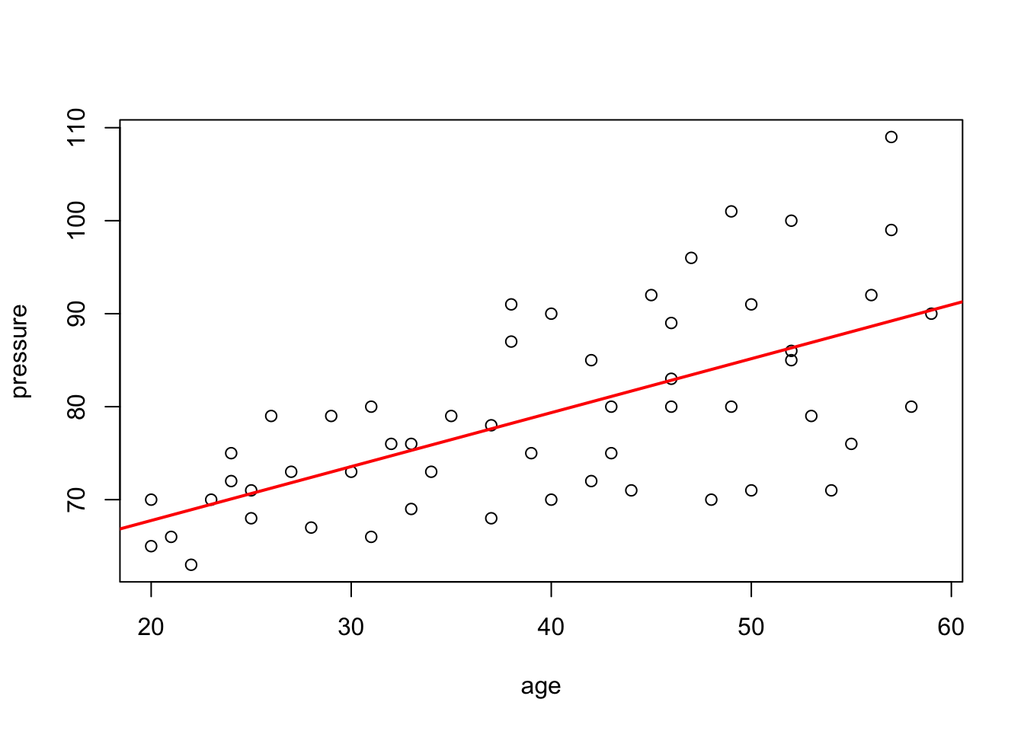

```r
plot(pressure ~ age, data=pressure)
abline(lm.pressure, col="red", lty=1, lwd=2)
```

where we observe a linear relationship between diastolic blood pressure and age.

When we look at the residual plot of fitted against residuals, we observe that the variance is not constant. In fact, it increases with age:

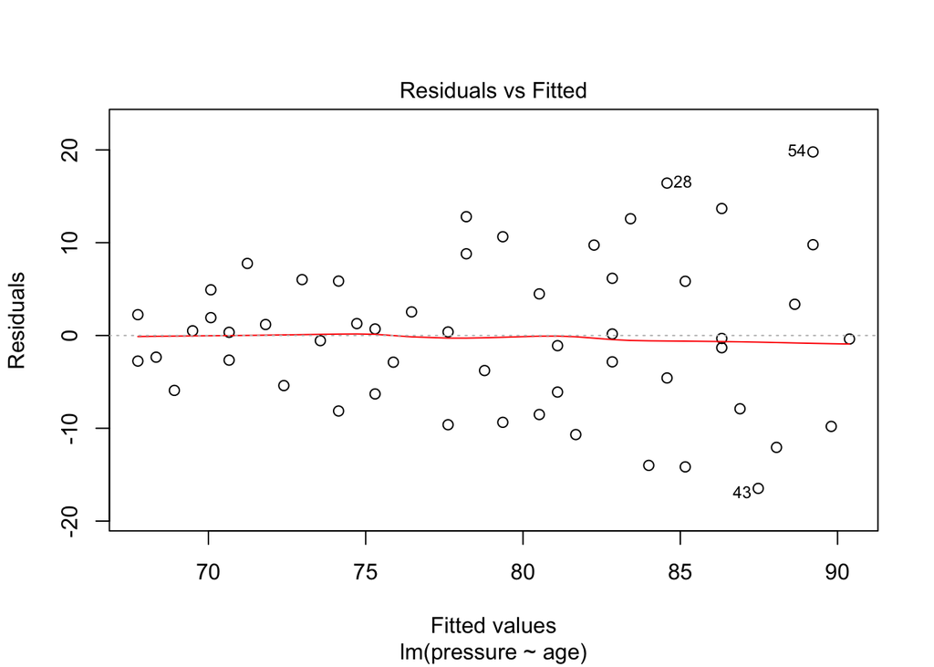

```r
plot(lm.pressure, which=1)
```

So, let us plot the **absolute residuals** against Age:

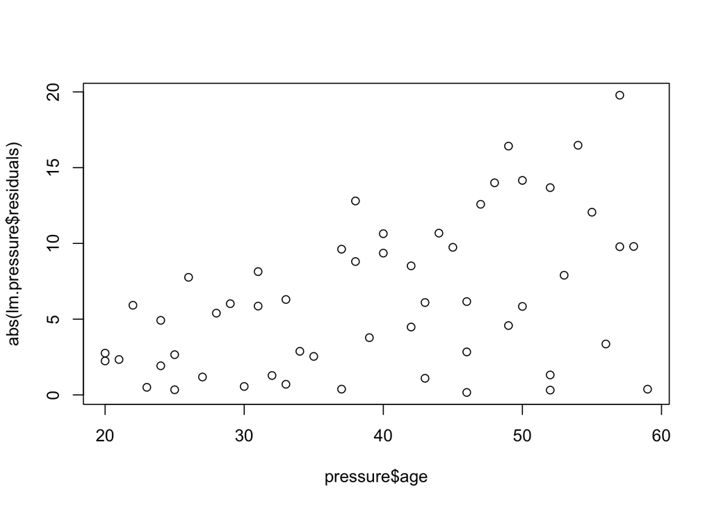

```r
plot(abs(lm.pressure$residuals) ~ pressure$age)
```

This plot suggests that a linear relation between the error standard deviation and Age may be reasonable, which means that we can use it to estimate the unknown standard deviation function. So, we fit a regression line between age and absolute residuals

```r
lm.resid = lm(abs(lm.pressure$residuals) ~ pressure$age)
summary(lm.resid)
```

```
##
## Call:
## lm(formula = abs(lm.pressure$residuals) ~ pressure$age)
##
## Residuals:
##     Min      1Q  Median      3Q     Max
## -9.7639 -2.7882 -0.1587  3.0757 10.0350
##
## Coefficients:
##              Estimate Std. Error t value Pr(>|t|)
## (Intercept)  -1.54948    2.18692  -0.709  0.48179
## pressure$age  0.19817    0.05309   3.733  0.00047 ***
## ---
## Signif. codes:  0 '***' 0.001 '**' 0.01 '*' 0.05 '.' 0.1 ' ' 1
##
## Residual standard error: 4.461 on 52 degrees of freedom
## Multiple R-squared:  0.2113, Adjusted R-squared:  0.1962
## F-statistic: 13.93 on 1 and 52 DF,  p-value: 0.0004705
```

We plot the fitted line along with the residuals:

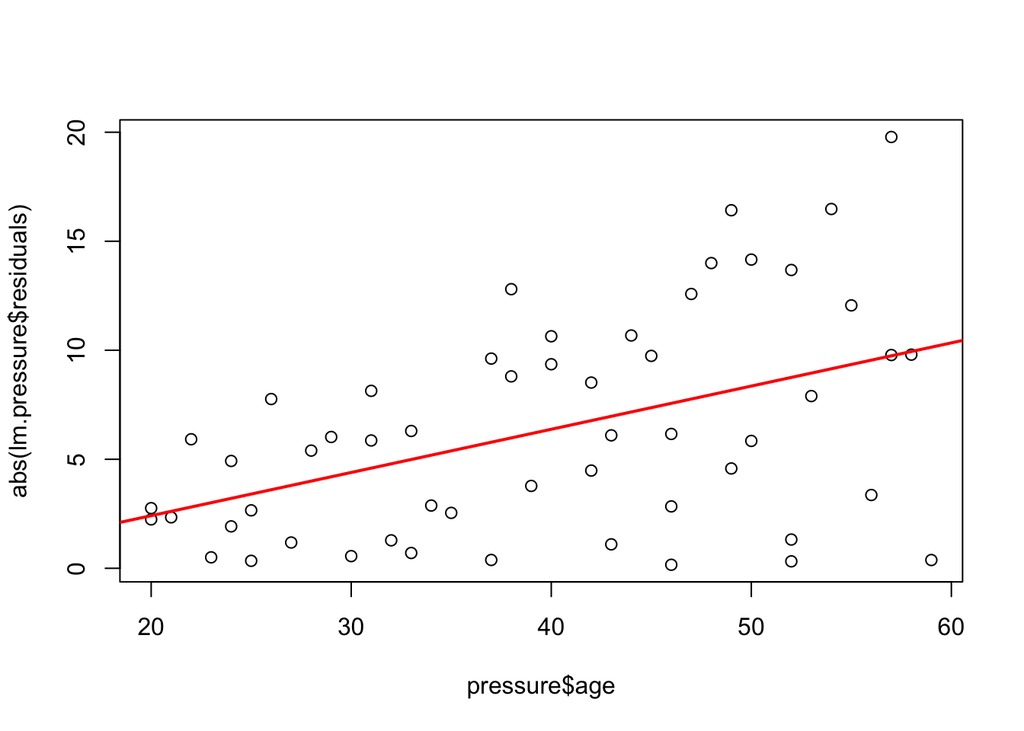

```r
plot(abs(lm.pressure$residuals) ~ pressure$age)
abline(lm.resid, col="red", lty=1, lwd=2)
```

The fitted values of this last regression model will be used to compute the weights:
$$w_i = \frac{1}{\hat{s}_i^2}$$
We compute them as follows:

```r
pressure$weight = 1/lm.resid$fitted.values^2
head(pressure)
```

```
##   age pressure     weight
## 1  27       73 0.06920928
## 2  21       66 0.14655708
## 3  22       63 0.12661657
## 4  24       75 0.09725115
## 5  25       71 0.08625993
## 6  23       70 0.11048521
```

Now, we are going to use these weights in a Weighted Least Squares regression and we will re-fit our model:

```r
lm.pressure.weights = lm(pressure~age, data=pressure, weights=weight)
summary(lm.pressure.weights)
```

```
##
## Call:
## lm(formula = pressure ~ age, data = pressure, weights = weight)
##
## Weighted Residuals:
##     Min      1Q  Median      3Q     Max
## -2.0230 -0.9939 -0.0327  0.9250  2.2008
##
## Coefficients:
##             Estimate Std. Error t value Pr(>|t|)
## (Intercept) 55.56577    2.52092  22.042  < 2e-16 ***
## age          0.59634    0.07924   7.526 7.19e-10 ***
## ---
## Signif. codes:  0 '***' 0.001 '**' 0.01 '*' 0.05 '.' 0.1 ' ' 1
##
## Residual standard error: 1.213 on 52 degrees of freedom
## Multiple R-squared:  0.5214, Adjusted R-squared:  0.5122
## F-statistic: 56.64 on 1 and 52 DF,  p-value: 7.187e-10
```

Finally, let us plot the raw data along with the two regression lines, with and without weights:

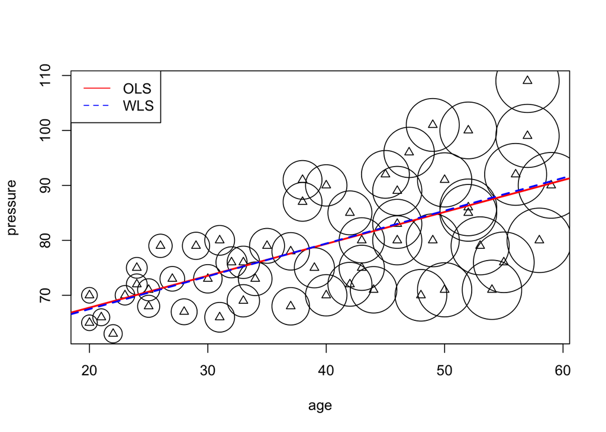

```r
plot(pressure ~ age, data=pressure, cex=lm.resid$fitted.values);
points(pressure ~ age, data=pressure, pch=2)
abline(lm.pressure, col="red", lty=1, lwd=2);
abline(lm.pressure.weights, col="blue", lty=2, lwd=2);
legend("topleft", col=c("red", "blue"), lty=c(1,2), legend=c("OLS", "WLS"))
```

We observe that the two fitted lines are not much different with each other. However, if we print the variance-covariance matrices

```r
vcov(lm.pressure)
```

```
##             (Intercept)          age
## (Intercept)  15.9494301 -0.371977563
## age          -0.3719776  0.009399527
```

```r
vcov(lm.pressure.weights)
```

```
##             (Intercept)          age
## (Intercept)   6.3550256 -0.189363636
## age          -0.1893636  0.006278666
```

we observe that **the variance of the WLS estimators are much smaller than the OLS estimators**.